# Challenge 9: Creating Nice Tables

Author

Fiona Norton

```r
library(dplyr)
library(tidyverse)
library(knitr)
library(DT)
library(kableExtra)
```

# The Data

```r
StateNames_A <- read.csv(here::here("supporting_artifacts", "datasets", "StateNames_A.csv"))
```

```r
kable(head(StateNames_A, 50),
      format = "html",
      align = c('crcrc'),
      booktabs = TRUE,
      caption = "Preview of First 50 Lines of Dataset") |>
  kable_minimal("hover", font_size = 12) |>
  scroll_box(width = "600px", height = "400px")
```

Preview of First 50 Lines of Dataset

| Name | Year | Gender | State | Count |
| --- | --- | --- | --- | --- |
| Ashley | 1997 | F | AK | 45 |
| Abigail | 1997 | F | AK | 32 |
| Alyssa | 1997 | F | AK | 32 |
| Amanda | 1997 | F | AK | 28 |
| Amber | 1997 | F | AK | 27 |
| Alexis | 1997 | F | AK | 25 |
| Alexandra | 1997 | F | AK | 20 |
| Anna | 1997 | F | AK | 20 |
| Allison | 1997 | F | AK | 19 |
| Alicia | 1997 | F | AK | 12 |
| Angela | 1997 | F | AK | 12 |
| Angel | 1997 | F | AK | 9 |
| Ariel | 1997 | F | AK | 9 |
| Ashlyn | 1997 | F | AK | 9 |
| Adriana | 1997 | F | AK | 7 |
| Alexandria | 1997 | F | AK | 7 |
| Anastasia | 1997 | F | AK | 7 |
| Andrea | 1997 | F | AK | 7 |
| Angelica | 1997 | F | AK | 7 |
| April | 1997 | F | AK | 7 |
| Arianna | 1997 | F | AK | 7 |
| Aurora | 1997 | F | AK | 7 |
| Autumn | 1997 | F | AK | 7 |
| Alice | 1997 | F | AK | 6 |
| Amelia | 1997 | F | AK | 6 |
| Amy | 1997 | F | AK | 6 |
| Ashleigh | 1997 | F | AK | 6 |
| Adrianna | 1997 | F | AK | 5 |
| Alexa | 1997 | F | AK | 5 |
| Alissa | 1997 | F | AK | 5 |
| Annie | 1997 | F | AK | 5 |
| Alyssa | 1998 | F | AK | 46 |
| Ashley | 1998 | F | AK | 43 |
| Alexis | 1998 | F | AK | 33 |
| Amber | 1998 | F | AK | 30 |
| Amanda | 1998 | F | AK | 24 |
| Abigail | 1998 | F | AK | 19 |
| Autumn | 1998 | F | AK | 19 |
| Alexandra | 1998 | F | AK | 17 |
| Amy | 1998 | F | AK | 17 |
| Anna | 1998 | F | AK | 17 |
| Alicia | 1998 | F | AK | 12 |
| Andrea | 1998 | F | AK | 12 |
| Alexandria | 1998 | F | AK | 11 |
| Alexa | 1998 | F | AK | 10 |
| Allison | 1998 | F | AK | 10 |
| Amelia | 1998 | F | AK | 10 |
| Angela | 1998 | F | AK | 9 |
| Aurora | 1998 | F | AK | 9 |
| Annie | 1998 | F | AK | 8 |

# Summarizing & Visualizing the Number of Allisons

```r
StateNames_A <- StateNames_A |>
  mutate("Sex at birth" = Gender) |>
  select(Name, Year, State, Count, `Sex at birth`)
```

### 1. Make a summary table of the number of babies named “Allison” for each state and the sex of the baby.

```r
Allisons_Table <- StateNames_A |>
  pivot_wider(names_from = `Sex at birth`, values_from = Count) |>
  filter(Name == "Allison") |>
  group_by(State) |>
  summarise(across(.cols = c('F', 'M'), .fns = sum)) |>
  mutate(across(.cols = c('F', 'M'), ~replace_na(.,0)))

kable(Allisons_Table,
      format = "html",
      col.names = c("State", "Frequency of Females", "Frequency of Males"),
      align = c('cll'),
      booktabs = TRUE,
      caption = "Number of Allisons in Each State by Sex") |>
  kable_minimal("hover", font_size = 12) |>
  scroll_box(width = "500px", height = "400px")
```

Number of Allisons in Each State by Sex

| State | Frequency of Females | Frequency of Males |
| --- | --- | --- |
| AK | 232 | 0 |
| AL | 1535 | 0 |
| AR | 1198 | 0 |
| AZ | 1880 | 0 |
| CA | 12413 | 0 |
| CO | 1594 | 0 |
| CT | 1099 | 0 |
| DC | 321 | 0 |
| DE | 294 | 0 |
| FL | 4455 | 0 |
| GA | 3257 | 0 |
| HI | 183 | 0 |
| IA | 1477 | 0 |
| ID | 451 | 0 |
| IL | 5110 | 0 |
| IN | 3067 | 0 |
| KS | 1283 | 0 |
| KY | 1905 | 0 |
| LA | 1209 | 0 |
| MA | 2218 | 0 |
| MD | 2229 | 0 |
| ME | 340 | 0 |
| MI | 4014 | 0 |
| MN | 2374 | 0 |
| MO | 2882 | 0 |
| MS | 817 | 0 |
| MT | 226 | 0 |
| NC | 3435 | 0 |
| ND | 285 | 0 |
| NE | 807 | 0 |
| NH | 412 | 0 |
| NJ | 3052 | 0 |
| NM | 399 | 0 |
| NV | 729 | 0 |
| NY | 5747 | 0 |
| OH | 5487 | 0 |
| OK | 1421 | 0 |
| OR | 1186 | 0 |
| PA | 4307 | 0 |
| RI | 306 | 0 |
| SC | 1228 | 0 |
| SD | 376 | 0 |
| TN | 2488 | 0 |
| TX | 10192 | 0 |
| UT | 1125 | 0 |
| VA | 3220 | 0 |
| VT | 135 | 0 |
| WA | 1956 | 0 |
| WI | 2367 | 0 |
| WV | 813 | 0 |
| WY | 142 | 0 |

### 2. Filter the data to include only babies assigned Female at birth.

```r
FemaleAllisons_Table <- StateNames_A|>
  filter(`Sex at birth` == 'F',
         Name == "Allison") |>
  group_by(State) |>
  summarise("FemaleAllisons" = sum(Count))

kable(FemaleAllisons_Table,
      format = "html",
      col.names = c("State", "Frequency of Females"),
      align = c('cc'),
      booktabs = TRUE,
      caption = "Number of Female Allisons in Each State") |>
  kable_minimal("hover", font_size = 12) |>
  scroll_box(width = "300px", height = "400px")
```

Number of Female Allisons in Each State

| State | Frequency of Females |
| --- | --- |
| AK | 232 |
| AL | 1535 |
| AR | 1198 |
| AZ | 1880 |
| CA | 12413 |
| CO | 1594 |
| CT | 1099 |
| DC | 321 |
| DE | 294 |
| FL | 4455 |
| GA | 3257 |
| HI | 183 |
| IA | 1477 |
| ID | 451 |
| IL | 5110 |
| IN | 3067 |
| KS | 1283 |
| KY | 1905 |
| LA | 1209 |
| MA | 2218 |
| MD | 2229 |
| ME | 340 |
| MI | 4014 |
| MN | 2374 |
| MO | 2882 |
| MS | 817 |
| MT | 226 |
| NC | 3435 |
| ND | 285 |
| NE | 807 |
| NH | 412 |
| NJ | 3052 |
| NM | 399 |
| NV | 729 |
| NY | 5747 |
| OH | 5487 |
| OK | 1421 |
| OR | 1186 |
| PA | 4307 |
| RI | 306 |
| SC | 1228 |
| SD | 376 |
| TN | 2488 |
| TX | 10192 |
| UT | 1125 |
| VA | 3220 |
| VT | 135 |
| WA | 1956 |
| WI | 2367 |
| WV | 813 |
| WY | 142 |

### 3. Make a visualization showing how the popularity of the name “Allison” has changed over the years.

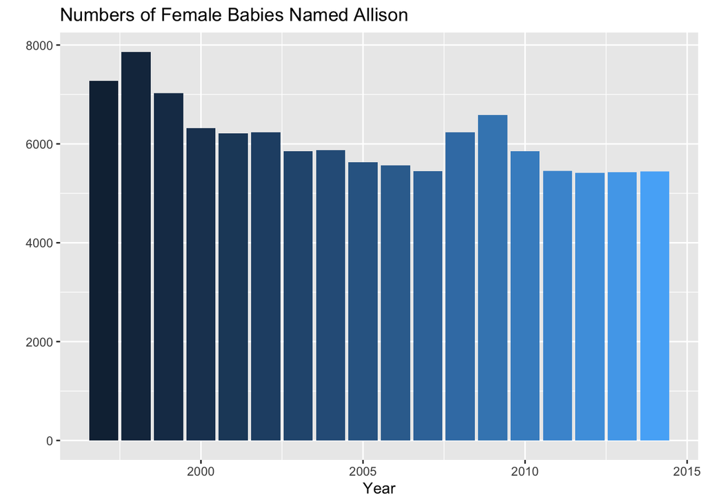

```r
StateNames_A|>
  filter(`Sex at birth` == 'F',
         Name == "Allison") |>
  ggplot(mapping = aes(x = Year, y = Count, fill = Year)) +
  geom_col() +
  labs(title = "Numbers of Female Babies Named Allison", x = "Year", y = "") +
  theme(legend.position = "none")
```

# Modeling the Number of Allisons

### 4. Create a linear model with the year as the explanatory variable, and the number of Allisons as the response.

```r
AllisonMod <- StateNames_A |>
  filter(Name == "Allison") |>
  lm(Count ~ Year, data = _)

summary(AllisonMod)
```

```
Call:
lm(formula = Count ~ Year, data = filter(StateNames_A, Name ==
    "Allison"))

Residuals:
    Min      1Q  Median      3Q     Max
-130.91  -90.77  -43.53   40.94  859.60

Coefficients:
             Estimate Std. Error t value Pr(>|t|)
(Intercept) 3881.8855  1765.2407   2.199   0.0281 *
Year          -1.8758     0.8802  -2.131   0.0333 *
---
Signif. codes:  0 '***' 0.001 '**' 0.01 '*' 0.05 '.' 0.1 ' ' 1

Residual standard error: 138 on 912 degrees of freedom
Multiple R-squared:  0.004955,  Adjusted R-squared:  0.003864
F-statistic: 4.542 on 1 and 912 DF,  p-value: 0.03335
```

### 5. Visualize the regression model.

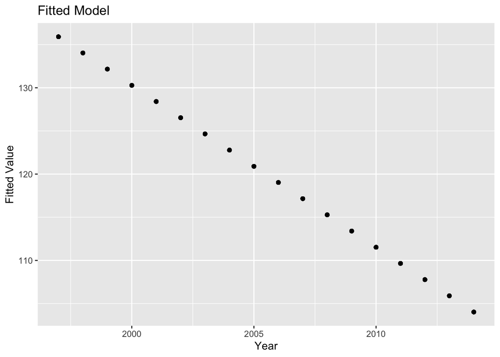

```r
AllisonMod |>
  broom::augment() |>
  ggplot(mapping = aes(x = Year, y = .fitted)) +
  geom_point() +
  labs(title = "Fitted Model", x = "Year", y = "Fitted Value")
```

### 6. Write out the estimated regression equation.

$$ŷ = 3881.88 - 1.876Year$$

### 7. Plot the residuals of the model, that is, the actual values minus the predicted values. Comment on the residuals - do you see any patterns?

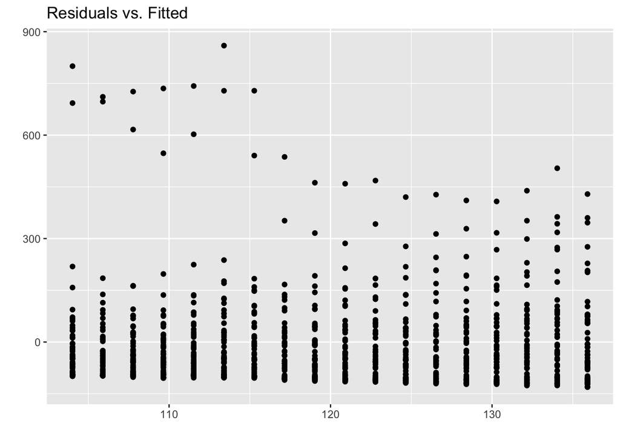

```r
AllisonMod |>
  broom::augment() |>
  ggplot(mapping = aes(y = .resid, x = .fitted)) +
  geom_point() +
  labs(title = "Residuals vs. Fitted", x = "", y = "")
```

The band of the residuals seems to get wider as the fitted values increase, excluding a few outliers.

### 8. What do you conclude from this model?

Based on the widening band of residuals and the simplicity of the model, we could probably find a better fit by including more variables.

# Spelling by State

### 9. Narrow the A name dataset (downloaded previously) down to only male-assigned babies named “Allan”, “Alan”, or “Allen”. Make a plot comparing the popularity of these names over time.

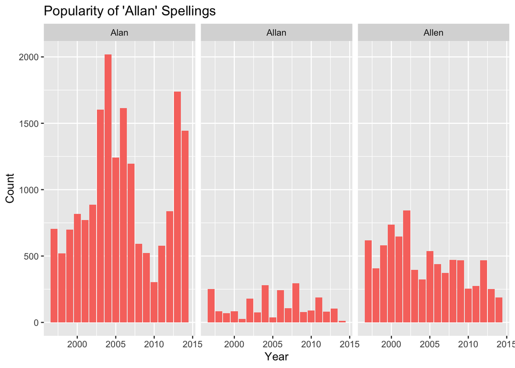

```r
allan_data <- StateNames_A |>
  filter(Name == c("Allan", "Allen", "Alan"),
         `Sex at birth` == 'M')

allan_data |>
  ggplot(mapping = aes(x = Year, y = Count, fill = "pink")) +
  geom_col() +
  facet_wrap(~Name) +
  theme(legend.position = "none") +
  labs(title = "Popularity of 'Allan' Spellings")
```

### 10. Compute the total number of babies born with each spelling of “Allan” in 2000, in Pennsylvania and in California.

```r
Allan_Table <- allan_data |>
  pivot_wider(names_from = Name, values_from = Count) |>
  filter(State == "PA" | State == "CA",
         Year == 2000) |>
  mutate(across(.cols = Allen:Allan, ~replace_na(.,0)))

kable(Allan_Table,
      format = "html",
      col.names = c("Year", "State", "Sex at Birth", "Frequency of 'Allen'",
                    "Frequency of 'Alan'", "Frequency of 'Allan'"),
      align = c('lllrrr'),
      booktabs = TRUE,
      caption = "Allan Babies in CA and PA by Spelling") |>
  kable_classic(font_size = 12)
```

Allan Babies in CA and PA by Spelling

| Year | State | Sex at Birth | Frequency of 'Allen' | Frequency of 'Alan' | Frequency of 'Allan' |
| --- | --- | --- | --- | --- | --- |
| 2000 | CA | M | 176 | 0 | 0 |
| 2000 | PA | M | 0 | 51 | 12 |

### 11. Convert your total counts to overall percents. That is, what was the percent breakdown between the three spellings in CA? What about in PA?

```r
Allan_Table_2 <- allan_data |>
  pivot_wider(names_from = Name, values_from = Count) |>
  mutate(across(.cols = Allen:Allan, ~replace_na(.,0))) |>
  filter(State == "PA" | State == "CA",
         Year == 2000) |>
  mutate(Allen = round(Allen / sum(across(Allen:Allan)), 2),
         Alan = round(Alan / sum(across(Allen:Allan)), 2),
         Allan = round(Allan / sum(across(Allen:Allan)), 2))

kable(Allan_Table_2,
      format = "html",
      col.names = c("Year", "State", "Sex at Birth", "Percent 'Allen'",
                    "Percent 'Alan'", "Percent 'Allan'"),
      align = c('lllrrr'),
      booktabs = TRUE,
      caption = "Percent of Total Allan Babies by Spelling in CA and PA") |>
  kable_classic(font_size = 12)
```

Percent of Total Allan Babies by Spelling in CA and PA

| Year | State | Sex at Birth | Percent 'Allen' | Percent 'Alan' | Percent 'Allan' |
| --- | --- | --- | --- | --- | --- |
| 2000 | CA | M | 0.74 | 0.0 | 0.00 |
| 2000 | PA | M | 0.00 | 0.8 | 0.89 |